# Lab 2 exercises

2024-03-02

[output not shown]

## Exercise 3

### a)

m := 2^32 a := 1664525 c := 1013904223 We have a recursive sequence so we shall use a for loop and take the value of the previous index. To make it less computationally expensive we will allocate the memory of X beforehand so that a copy needn’t be created each iteration This can be done with the numeric(x) function. I have chosen the seed as X_1 = 1 U is then defined to be the set of X / m which can then be plotted with the hist function.

### b)

Once again we allocate the memory for the vectors beforehand. Next we want to choose replicable random numbers from the set U. Here i have chosen to take values every multiple of 3 for the X coordinates and every multiple of 5 for the Y coordinates. Any sequence can be used here as long as it produces values within [1, 10000]

### c)

The points tend to form more clusetered patches in some areas with large spaces in other areas

### d)

Randomly created sequences chosen, a +1 was required on a few as a_1 would evaluate to zero

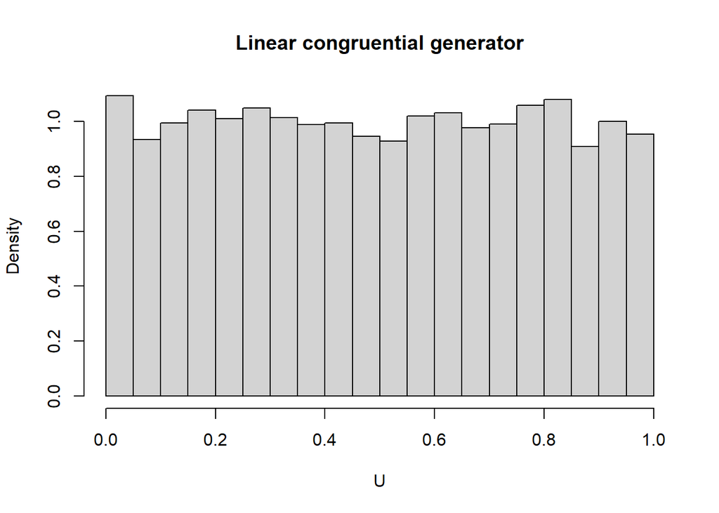

```r
#a)
m = 2^32
a = 1664525
c = 1013904223
X = numeric(10000)
X[1] = 1
for(i in 2:10000){
  X[i] = ((a * X[i - 1] + c) %% m)
}
U = c(X / m)
hist(U, prob = TRUE, main = "Linear congruential generator")
```

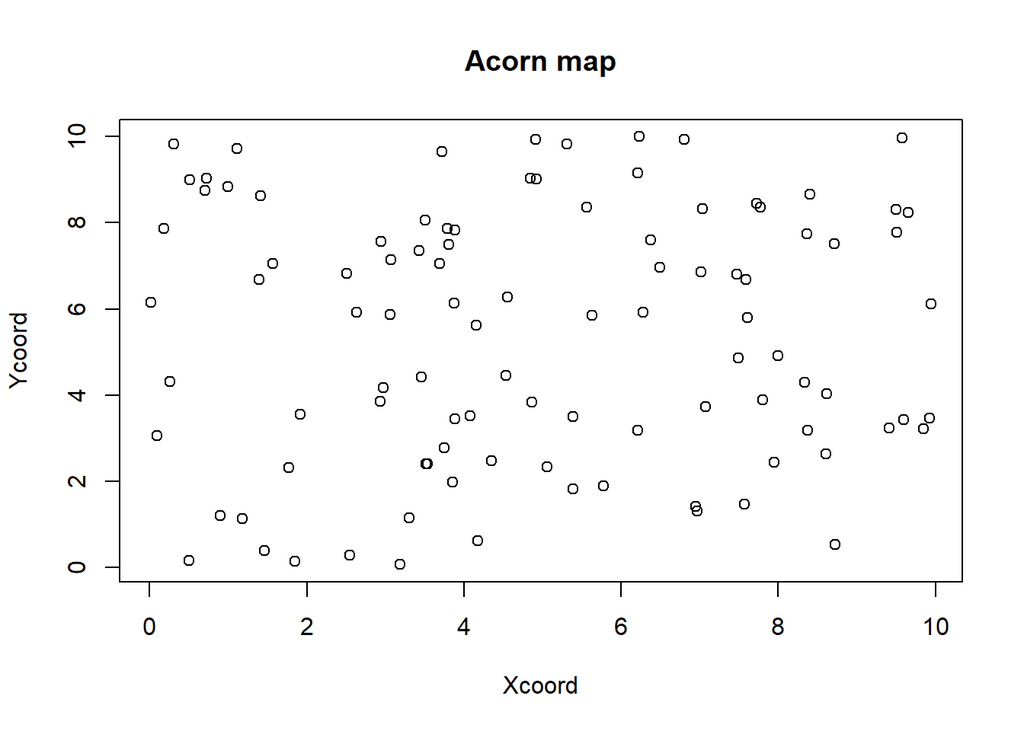

```r
#b)
Xcoord = numeric(100)
Ycoord = numeric(100)
for(i in 1:100){
  Xcoord[i] = U[3 * i] * 10
  Ycoord[i] = U[5 * i] * 10
}
plot(Xcoord, Ycoord, main = "Acorn map")
```

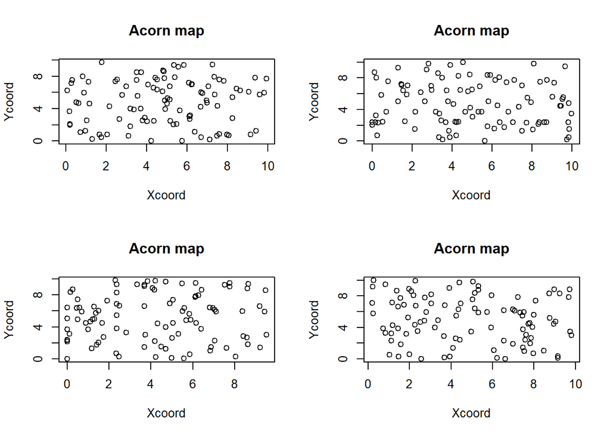

```r
#d)
par(mfrow=c(2,2))
Xcoord = numeric(100)
Ycoord = numeric(100)
# Plot 1
for(i in 1:100){
  Xcoord[i] = U[4 * i + 1] * 10
  Ycoord[i] = U[10001 - i^2] * 10
}
plot(Xcoord, Ycoord, main = "Acorn map")

# Plot 2
for(i in 1:100){
  Xcoord[i] = U[floor(10 * log10(i)) + i] * 10
  Ycoord[i] = U[ceiling(2^(i / 9))] * 10
}
plot(Xcoord, Ycoord, main = "Acorn map")

#Plot 3
for(i in 1:100){
  Xcoord[i] = U[floor(exp(i / 11))] * 10
  Ycoord[i] = U[1/2*i*(i-1) + 1] * 10
}
plot(Xcoord, Ycoord, main = "Acorn map")

#Plot 4
#Plot 3
for(i in 1:100){
  Xcoord[i] = U[1 + i + i^2] * 10
  Ycoord[i] = U[10 * i] * 10
}
plot(Xcoord, Ycoord, main = "Acorn map")
```